# VM Coding Challenge

Instructions: • Look through the attached CSV file and perform the tasks outlined below. • All code should be written in python. • To submit your challenge results, include all applicable files in a zipped file with the following folder naming convention: FirstInitial_LastName.zip (ex. JDoe.zip) • We recommend providing answers in the form of a Juypter notebook, using markdown cells to add commentary and explain any assumptions.

#### 1. Write a function to compute, for a given subreddit, the average upvotes per post over time. What insights can you draw from this?

##### Data cleaning.

```python
#pip install sklearn
import pandas as pd
import numpy as np
import matplotlib.pyplot as plt
import seaborn as sns
from sklearn.metrics import mean_squared_error, r2_score, mean_absolute_error
from sklearn.model_selection import train_test_split
from sklearn.preprocessing import LabelBinarizer
from sklearn.dummy import DummyRegressor
from sklearn.linear_model import LinearRegression
from sklearn.linear_model import LassoCV
from sklearn.linear_model import RidgeCV
from sklearn.linear_model import ElasticNetCV
from sklearn.neighbors import KNeighborsRegressor
from sklearn.tree import DecisionTreeRegressor
from sklearn.ensemble import RandomForestRegressor
from sklearn.ensemble import GradientBoostingRegressor
import warnings
warnings.filterwarnings('ignore')

rawdata = pd.read_excel('/Users/phoebe/Desktop/CodingChallenge.xlsx' )
print(rawdata['up_votes'].isnull().sum())
print(rawdata['subreddit'].isnull().sum())
# some posts don't have subreddit type, since 19 is relatively small number, I decided to drop the NAN at this time.
data = rawdata.dropna(subset=['subreddit'])
print(data['up_votes'].describe())
```

```
0
19
count     17029.000000
mean      10022.072817
std       10963.930024
min          -1.000000
25%        2267.000000
50%        6799.000000
75%       13489.000000
max      240725.000000
Name: up_votes, dtype: float64
```

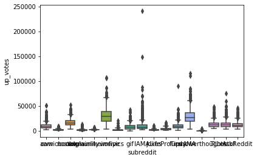

```python
cols = data.columns
plt.xlabel(cols[6])
plt.ylabel(cols[3])
sns.boxplot(x = 'subreddit', y = 'up_votes', data =  rawdata)

plt.show()
```

##### We can see the distribution of up_votes by subreddit.

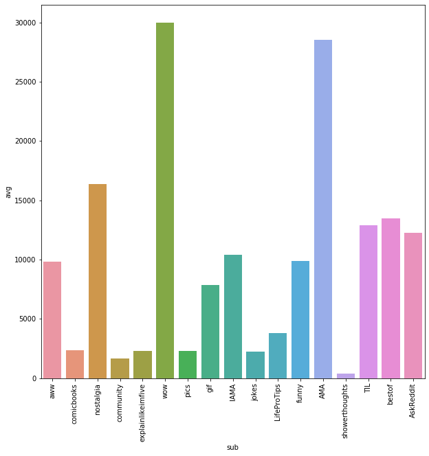

```python
def avgUpvotes(sub):
    return data.loc[(data.subreddit == sub)]['up_votes'].mean()

def std(sub):
    return data.loc[(data.subreddit == sub)]['up_votes'].stdev()

value = data.subreddit.unique()
sub = []
avg = []

for i in value:
    sub.append(i)
    avg.append(avgUpvotes(i))

d = {'sub': sub, 'avg': avg}
df = pd.DataFrame(data=d)

cols = df.columns
plt.figure(figsize=(10,10))
plt.xlabel(cols[0])
plt.ylabel(cols[1])
plt.xticks(rotation=90)
sns.barplot(x = 'sub', y = 'avg', data =  df)

plt.show()
```

##### Based on the result, people are more willing to upvote the posts that are expresive.

### 2. Is there a day of the week for which posts receive significantly more upvotes than other days?

#### Need to convert the date to Categorical data.

```python
import datetime
from datetime import date
import calendar

data = data.rename(columns={"created_epoch_date": "date"})
for i in data['date']:
    data.loc[(data.date == i),'date']= time.strftime('%Y-%m-%d', time.localtime(i))

#print(data['date'])
```

```python
def findDay(date):
    year, month, day = (int(i) for i in date.split('-'))
    born = datetime.date(year, month, day)
    return born.strftime("%A")

# Driver program
weekday = []
for i in data['date']:
    weekday.append(findDay(i))

data['weekday'] = weekday
#print(data)
```

[output not shown]

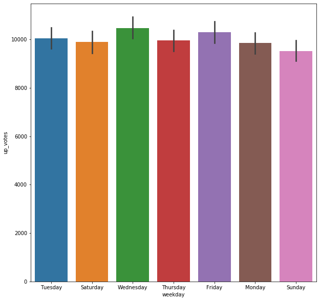

```python
plt.figure(figsize=(10,10))
cols = data.columns
plt.xlabel(cols[7])
plt.ylabel(cols[3])
sns.barplot(x = 'weekday', y = 'up_votes', data = data)

plt.show()
```

### 3. Can you predict the average number of comments per post for each subreddit for the remainder of 2020?

```python
col = data.columns
for i in col:
    print(data[i].isnull().sum())
#There is no nan value in the data now.
data3 = data[['date','weekday','up_votes','down_votes','num_comments','subreddit']]

#The data we need is weekday, up and down votes, num of comments and subreddit. We don't need the ID since every id is unique, and we also don't need the title of the post at this time, if not envolving text analysis.
#Since the weekday is categorical data, we need to convert to the numerical data
data3.loc[(data3.weekday == 'Monday'),'weekday']= 1
data3.loc[(data3.weekday == 'Tuesday'),'weekday']= 2
data3.loc[(data3.weekday == 'Wednesday'),'weekday']= 3
data3.loc[(data3.weekday == 'Thursday'),'weekday']= 4
data3.loc[(data3.weekday == 'Friday'),'weekday']= 5
data3.loc[(data3.weekday == 'Saturday'),'weekday']= 6
data3.loc[(data3.weekday == 'Sunday'),'weekday']= 7
data3
```

```
0
0
0
0
0
0
0
0
```

|  | date | weekday | up_votes | down_votes | num_comments | subreddit |
| --- | --- | --- | --- | --- | --- | --- |
| 0 | 2019-04-30 | 2 | 35990 | 23076 | 44169 | aww |
| 1 | 2020-01-04 | 6 | 24236 | 18357 | 9590 | aww |
| 2 | 2019-06-05 | 3 | 28081 | 22724 | 3506 | aww |
| 3 | 2019-04-25 | 4 | 37859 | 32554 | 4470 | aww |
| 4 | 2019-12-05 | 4 | 16341 | 11394 | 9747 | aww |
| ... | ... | ... | ... | ... | ... | ... |
| 17043 | 2020-08-08 | 6 | 14233 | 11873 | 1055 | AskReddit |
| 17044 | 2020-05-07 | 4 | 18626 | 16265 | 3022 | AskReddit |
| 17045 | 2020-03-20 | 5 | 12589 | 10228 | 2660 | AskReddit |
| 17046 | 2020-02-19 | 3 | 5275 | 2917 | 566 | AskReddit |
| 17047 | 2019-11-21 | 4 | 11027 | 8668 | 702 | AskReddit |

17029 rows × 6 columns

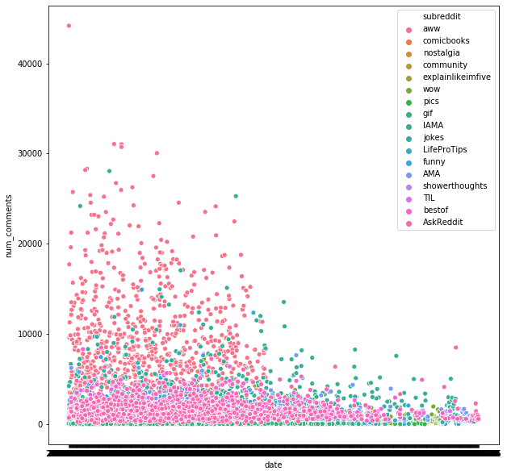

```python
fig, ax1 = plt.subplots(figsize=(10,10))
sns.scatterplot(data=data3, x="date", y="num_comments", hue="subreddit")
plt.show()
```

```python
from sklearn.model_selection import train_test_split
year = []
def to_integer(date):
    year, month, day = (int(i) for i in date.split('-'))
    return year

for i in data3['date']:
    year.append(to_integer(i))

data3['year'] = year

by_sub = []
for sub, df_sub in data3.groupby('subreddit'):
    by_sub.append(df_sub)
```

```python
from sklearn.model_selection import train_test_split
import numpy

train ,test = train_test_split(by_sub[1],test_size=0.2)
print(test)
```

```
             date weekday  up_votes  down_votes  num_comments  subreddit  year
16964  2019-06-06       4      7922        5511           949  AskReddit  2019
16829  2020-05-22       5     17670       15151          2724  AskReddit  2020
16993  2020-05-18       1     12870       10482          1054  AskReddit  2020
16791  2019-07-11       4      9598        7054          1505  AskReddit  2019
16089  2018-09-21       5     31097       27300          4134  AskReddit  2018
...           ...     ...       ...         ...           ...        ...   ...
16293  2020-07-03       5     25299       22197          1529  AskReddit  2020
16256  2019-09-27       5     17344       14174           992  AskReddit  2019
16682  2019-09-22       7      6647        3999          1636  AskReddit  2019
16978  2020-06-25       4      7963        5561          1827  AskReddit  2020
16862  2018-03-20       2      7591        5109           603  AskReddit  2018

[200 rows x 7 columns]
```

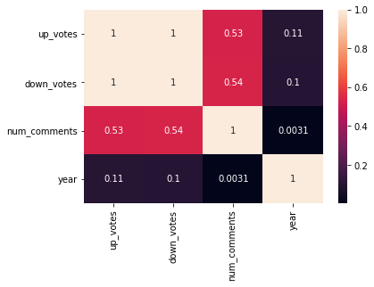

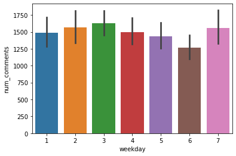

```python
corrMatrix = train.corr()

sns.heatmap(corrMatrix, annot=True)
plt.show()
#We can see that number of comments is kind of correlated to the up and down votes. We can also see the error bar is overlapped here, so we ignore weekday at this time.

cols = train.columns
plt.xlabel(cols[1])
plt.ylabel(cols[4])
sns.barplot(x = 'weekday', y = 'num_comments', data = train)

plt.show()
```

```python
model_performance_dict = dict()
```

```python
y_train = train.num_comments
x_train = train[['up_votes','down_votes']]
y_test = test.num_comments
x_test = test[['up_votes','down_votes']]
```

```python
def model_diagnostics(model, pr=True):
    """
    Returns and prints the R-squared, RMSE and the MAE for a trained model
    """
    y_predicted = model.predict(x_test)
    r2 = r2_score(y_test, y_predicted)
    mse = mean_squared_error(y_test, y_predicted)
    mae = mean_absolute_error(y_test, y_predicted)
    if pr:
        print(f"R-Sq: {r2:.4}")
        print(f"RMSE: {np.sqrt(mse)}")
        print(f"MAE: {mae}")

    return [r2,np.sqrt(mse),mae]
```

```python
baseline = DummyRegressor(strategy='mean')
baseline.fit(x_train,y_train)
model_performance_dict["Baseline"] = model_diagnostics(baseline)
```

```
R-Sq: -0.01285
RMSE: 1163.3671487066763
MAE: 887.1452823086574
```

```python
linear = LinearRegression()
linear.fit(x_train,y_train)
model_performance_dict["Linear Regression"] = model_diagnostics(linear)
```

```
R-Sq: 0.2954
RMSE: 970.3330050036893
MAE: 741.133366704739
```

```python
lasso = LassoCV(cv=30).fit(x_train, y_train)
model_performance_dict["Lasso Regression"] = model_diagnostics(lasso)
```

```
R-Sq: 0.287
RMSE: 976.0736488129842
MAE: 742.8083160975326
```

```python
ridge = RidgeCV(cv=10).fit(x_train, y_train)
model_performance_dict["Ridge Regression"] = model_diagnostics(ridge)
```

```
R-Sq: 0.2954
RMSE: 970.3330063521483
MAE: 741.13336707543
```

```python
elastic_net = ElasticNetCV(cv = 30).fit(x_train, y_train)
model_performance_dict["Elastic Net Regression"] = model_diagnostics(elastic_net)
```

```
R-Sq: 0.287
RMSE: 976.0667740038623
MAE: 742.8282324368498
```

```python
knr = KNeighborsRegressor()
knr.fit(x_train, y_train)
model_performance_dict["KNN Regression"] = model_diagnostics(knr)
```

```
R-Sq: 0.1389
RMSE: 1072.7086106674076
MAE: 812.235
```

```python
gbr = GradientBoostingRegressor(n_estimators=70, max_depth=5)
gbr.fit(x_train, y_train)
model_performance_dict["Gradient Boosting Regression"] = model_diagnostics(gbr)
```

```
R-Sq: 0.1997
RMSE: 1034.1397603591188
MAE: 769.882583435879
```

```python
def model_comparison(model_performance_dict, sort_by = 'RMSE', metric = 'RMSE'):

    Rsq_list = []
    RMSE_list = []
    MAE_list = []
    for key in model_performance_dict.keys():
        Rsq_list.append(model_performance_dict[key][0])
        RMSE_list.append(model_performance_dict[key][1])
        MAE_list.append(model_performance_dict[key][2])

    props = pd.DataFrame([])

    props["R-squared"] = Rsq_list
    props["RMSE"] = RMSE_list
    props["MAE"] = MAE_list
    props.index = model_performance_dict.keys()
    props = props.sort_values(by = sort_by)

    fig, ax = plt.subplots(figsize = (12,6))

    ax.bar(props.index, props[metric], color="blue")
    plt.title(metric)
    plt.xlabel('Model')
    plt.xticks(rotation = 45)
    plt.ylabel(metric)
```

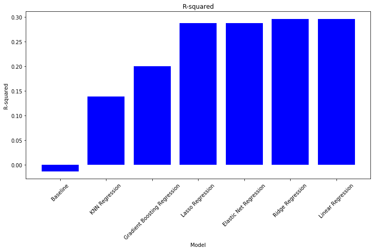

```python
model_comparison(model_performance_dict, sort_by = 'R-squared', metric = 'R-squared')
```

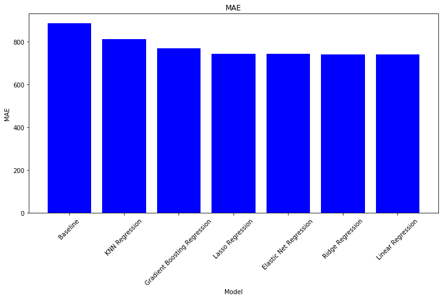

```python
model_comparison(model_performance_dict, sort_by = 'R-squared', metric = 'MAE')
```

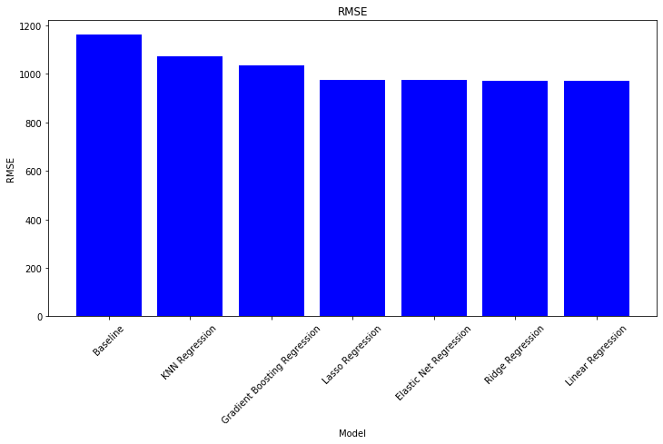

```python
model_comparison(model_performance_dict, sort_by = 'R-squared', metric = 'RMSE')
```

#### We can see that the relatively best model at this time is Linear Regression and Ridge regression.

```python
def findBestModel(dataset):
    train ,test = train_test_split(dataset,test_size=0.2)
    corrMatrix = train.corr()
    model_performance_dict = dict()
    y_train = train.num_comments
    x_train = train[['up_votes','down_votes']]
    y_test = test.num_comments
    x_test = test[['up_votes','down_votes']]
    #baseline Model
    baseline = DummyRegressor(strategy='mean')
    baseline.fit(x_train,y_train)
    model_performance_dict["Baseline"] = model_diagnostics(baseline)
    #linear Model
    linear = LinearRegression()
    linear.fit(x_train,y_train)
    model_performance_dict["Linear Regression"] = model_diagnostics(linear)
    #Lasso
    lasso = LassoCV(cv=30).fit(x_train, y_train)
    model_performance_dict["Lasso Regression"] = model_diagnostics(lasso)
    #ridge
    ridge = RidgeCV(cv=10).fit(x_train, y_train)
    model_performance_dict["Ridge Regression"] = model_diagnostics(ridge)
    #Elastic Net
    elastic_net = ElasticNetCV(cv = 30).fit(x_train, y_train)
    model_performance_dict["Elastic Net Regression"] = model_diagnostics(elastic_net)
    #Knn
    knr = KNeighborsRegressor()
    knr.fit(x_train, y_train)
    model_performance_dict["KNN Regression"] = model_diagnostics(knr)
    #GBR
    gbr = GradientBoostingRegressor(n_estimators=70, max_depth=5)
    gbr.fit(x_train, y_train)
    model_performance_dict["Gradient Boosting Regression"] = model_diagnostics(gbr)
    return dataset['subreddit'], model_performance_dict,model_comparison(model_performance_dict, sort_by = 'R-squared', metric = 'R-squared'),model_comparison(model_performance_dict, sort_by = 'R-squared', metric = 'RMSE')
```

```python
"""for i in by_sub:
    print(findBestModel(i))"""
```

```
'for i in by_sub:\n    print(findBestModel(i))'
```

```
R-Sq: -0.006438
RMSE: 1159.6803327503587
MAE: 892.0240150564618
R-Sq: 0.2995
RMSE: 967.4842517665791
MAE: 746.4740670277781
R-Sq: 0.2878
RMSE: 975.5415393880984
MAE: 749.1011964620926
R-Sq: 0.2995
RMSE: 967.4842534563342
MAE: 746.4740674401296
R-Sq: 0.2878
RMSE: 975.5491982573851
MAE: 749.1388718194956
R-Sq: 0.4222
RMSE: 878.6712994060975
MAE: 676.2819999999999
R-Sq: 0.583
RMSE: 746.4469675366264
MAE: 561.819939927592
```

```
(16051    AskReddit
 16052    AskReddit
 16053    AskReddit
 16054    AskReddit
 16055    AskReddit
            ...
 17043    AskReddit
 17044    AskReddit
 17045    AskReddit
 17046    AskReddit
 17047    AskReddit
 Name: subreddit, Length: 997, dtype: object,
 {'Baseline': [-0.006438496063760901, 1159.6803327503587, 892.0240150564618],
  'Linear Regression': [0.29951560421060186,
   967.4842517665791,
   746.4740670277781],
  'Lasso Regression': [0.28779963859279845,
   975.5415393880984,
   749.1011964620926],
  'Ridge Regression': [0.29951560176374625,
   967.4842534563342,
   746.4740674401296],
  'Elastic Net Regression': [0.2877884557355531,
   975.5491982573851,
   749.1388718194956],
  'KNN Regression': [0.4222186248316754, 878.6712994060975, 676.2819999999999],
  'Gradient Boosting Regression': [0.5830263874204642,
   746.4469675366264,
   561.819939927592]},
 None,
 None)
```

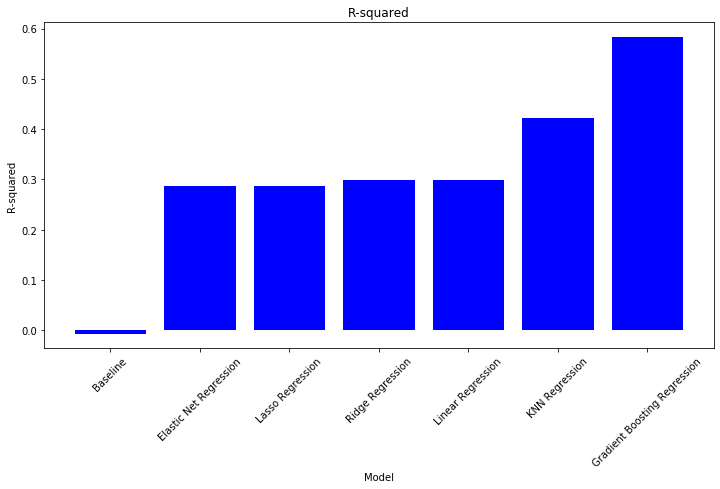

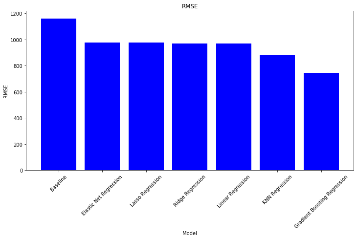

```python
findBestModel(by_sub[1])
```

```python
def plot_residuals(y_test, y_predicted):
    """"
    Plots the distribution for actual and predicted values of the target variable. Also plots the distribution for the residuals
    """
    fig, (ax0, ax1) = plt.subplots(nrows=1, ncols=2, sharey=True)
    sns.distplot(y_test, ax=ax0, kde = False)
    ax0.set(xlabel='Test scores')
    sns.distplot(y_predicted, ax=ax1, kde = False)
    ax1.set(xlabel="Predicted scores")
    plt.show()
    fig, ax2 = plt.subplots()
    sns.distplot((y_test-y_predicted), ax = ax2,kde = False)
    ax2.set(xlabel="Residuals")
    plt.show()
```

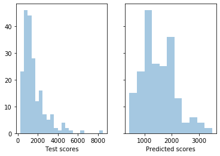

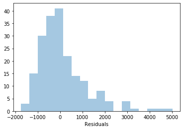

```python
y_predicted = gbr.predict(x_test)
plot_residuals(y_test,y_predicted)
```